# regularization

```python
import pandas as pd
import matplotlib.pyplot as plt
import numpy as np
%config IPCompleter.greedy=True
```

## Regularization Methods

Regularization methods help prevent overfitting. The basic idea is to reduce variance by allowing some bias.

### Ridge Regression

https://www.youtube.com/watch?v=Q81RR3yKn30&t=14s

Say we start with a linear regression that looks something like this:  
$size = 0.4 + 1.3 \times weight$

With a lot of measurements, we can be somewhat sure the equation represents something close to the true relationship between size and weight.

Linear regression finds coefficients/weights by minimizing the sum of squared residuals, or SSR:

$\sum_{i=1}^{n} \left ( y_i - \hat{y_i} \right )^2$

If we only have 2 measurements, the SSR is 0... it's simply a line connecting the 2 points.

If we apply this model created with 2 measurements to a new set of data, it will likely have a high SSR. We would say our model has high variance... despite the line being a perfect predictor of the training set, it is **overfit** to the training data, and will likely not fit new data well.

In ridge regression, the idea is to fit a line that doesn't fit the training data as well. (Wait, what!?) No really... we introduce a little bias to get a meaningful drop in variance. With a slightly worse fit on the training data, we can get better long term predictions.

We accomplish this tradeoff by penalizing the coefficients in the model.

#### Ridge Regression Penalty

Linear Regression:  
$size = intercept + slope \times weight$, where the slope selected minimizes the SSR

Ridge Regression:  
Minimizes $SSR + \lambda \times slope^2$,

or more formally for multiple predictors:

$\sum_{i=1}^{n} \left ( y_i - \hat{y_i} \right )^2 + \lambda \times \sum_{j=1}^{p} \beta_{j}^2 $

The second term is the penalty added to the least squares method. $\lambda$ is the severity of the penality.

So, for our equation fit with 2 data points:

$size = 0.4 + 1.3 \times weight$

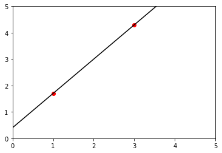

```python
x = [1, 3]
y = [1.7, 4.3]
x_line = [0, 6]
y_line = [0.4, 8.2]
plt.plot(x, y, 'ro')
plt.plot(x_line, y_line, 'k-')
plt.xlim(0,5)
a = plt.ylim(0,5)
```

We just draw a line through the two points. The error is 0, as is the SSR, since of course summing up the 0 error is just 0.

Let's set $\lambda = 1$ and see what happens.

$adjusted SSR = 0 + 1 \times 1.3^2 = 1.69$

That's what happens when we use the adjusted SSR on our current equation. If we perform ridge regression and select weights by minimizing the SSR + penalty, we get a different equation:

$size = 0.9 + 0.8 \times weight$

So, the adjusted SSR is lower for ridge regression.

Linear regression is unbiased but has high variance. With ridge, we've introduced some bias, but it should fit the new data better.

When the slope of our model line is small, predictions are lsss sensitive to changes in weight.

A ridge regression line will have a smaller slope, so predictions with ridge regression are less sensitive.

#### Choosing $\lambda$

$\lambda$ can take on any value from $[0, \infty]$

If $\lambda = 0$, ridge regression and least squares are the same (since the penalty is nullified). The higher the $\lambda$, the smaller the slope of the resulting fit line. As we increase $\lambda$ to infinity, the slope gets closer to 0.

How do we choose $\lambda$? The most typical method is 10-fold cross validation.

#### Discrete data

Ridge regression will work with discrete data as well.  
$size = 0.5 + 0.8 \times highfatdiet$

Let's pretend we're predicting the size of mice based on whether they were on a high fat diet vs a normal diet (whatever normal diet means in this case).

So, ridge regression will shrink the slope, and therefore shrink the effect of differences due to diet.

This is very useful with small sample sizes.

#### Ridge in logistic regression

$isobese = intercept + slope \times weight$

As with linear regression, ridge will still shrink the slope, making the prediction of obesity less sensitive to weight.

In this case, ridge optimizes the sum of the likelihoods instead of the squared residuals.

#### What if there's more than one x variable?

In general, the ridge regression penalty contains all parameters except the y-intercept. It's just applied to every slope.

$\lambda(\text{dietdifference}^2 + \text{astrologicaloffset}^2 + \text{airspeed}^2)$

Every parameter is scaled by the measurements... and that's why we don't include the y-intercept.

#### One of the coolest things about ridge regression? (Maybe a bit subjective)

In linear regression, to make a line, we need at least 2 points. So to fit one linear regression model, we need at least 2 data points. But, if we have 3 parameters, 2 data points isn't enough. We have to fit a plane. So, we need 3 parameters. With 10,001 parameters, we need 10,001 data points.

What if we have an equation with 10,000 parameters... but only 500 samples?

Ridge regression can do it! We can solve with fewer samples than parameters using cross validation.

#### Summary

When sample sizes are small, ridge regression can improve predictions made on new data (reduce variance) by making the predictions less sensitive to the training data.

This is done by adding ridge regression penalty to whatever is being minimized.

Even with fewer samples than variables/parameters, ridge regression can get estimates using cross validation.

### Lasso Regression

Ridge = linear regression with ridge penalty (squared $\beta$s multiplied by a regularization parameter $\lambda$)

Ridge has more bias than linear regression, but at the gain of a more meaningful drop in variance.

Lasso is similar, but instead of squaring, we take absolute values:

$\sum_{i=1}^{n} \left ( y_i - \hat{y_i} \right )^2 + \lambda \times \sum_{j=1}^{p} \left | \beta_{j} \right |$

As with ridge, lasso trades off a gain in bias for a decrease in variance.

#### How else are lasso and ridge regression similar?

Both lasso and ridge:

- Make predictions less sensitive to small sample sizes
- Can be applied in the same contexts:
  - Linear regression
  - Logistic regression
  - Other more complicated models... the point is they can applied in a similar fashion

When either ridge/lasso shrink parameters, they don't have to shrink them all equally.

An example using a binary variable for whether the subject was on a high fat diet (red points/line in plot below) or a normal diet (green points/line).

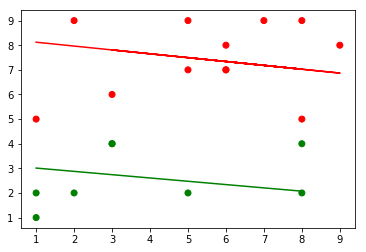

```python
np.random.seed(1)
randomdata = {'x' : np.random.randint(low = 1, high = 10, size = 20), 'y' : np.random.randint(low = 1, high = 10, size = 20)}
randomdata = pd.DataFrame(data = randomdata)
randomdata['highfatdiet'] = randomdata['y'] > 4
randomdata['xiyi'] = randomdata['x'] * randomdata['y']
randomdata['xsq']  = randomdata['x']**2
means = randomdata.groupby('highfatdiet')[['x','y']].mean()
sums  = randomdata.groupby('highfatdiet')[['x','y','xsq','xiyi']].sum()
xbar_norm, xbar_high = means['x'][0], means['x'][1]
ybar_norm, ybar_high = means['y'][0], means['y'][1]
xiyisum_norm, xiyisum_high = sums['xiyi'][0], sums['xiyi'][1]
xsum_norm, xsum_high= sums['x'][0], sums['x'][1]
xsqsum_norm, xsqsum_high  = sums['xsq'][0], sums['xsq'][1]

b1_high = (xiyisum_high - (ybar_high * xsum_high)) / ((xbar_high * xsum_high) - xsqsum_high)
b0_high = ybar_high - b1_high*xbar_high

b1_norm = (xiyisum_norm - (ybar_norm * xsum_norm)) / ((xbar_norm * xsum_norm) - xsqsum_norm)
b0_norm = ybar_norm - b1_norm*xbar_norm

line_high = randomdata[randomdata['highfatdiet'] == True]['x'] * b1_high + b0_high
line_norm = randomdata[randomdata['highfatdiet'] == False]['x'] * b1_norm + b0_norm

randomdata['colors'] = np.where(randomdata['highfatdiet'] == True,'red', 'green')

plt.scatter(randomdata['x'],randomdata['y'],marker='o', c = randomdata['colors'])
plt.plot(randomdata[randomdata['highfatdiet'] == True]['x'], line_high, c = 'red')
a = plt.plot(randomdata[randomdata['highfatdiet'] == False]['x'], line_norm, c = 'green')
```

The vertical distance between these lines is the difference in diets.

Regularization may shrink these lines closer to one another more strongly than it shrinks their slopes.

#### Now, how are ridge and lasso different?

Ridge: Shrinks the slope asymptotically close to 0  
Lasso: Can shrink the slope all the way to 0

$size = \beta_0 + slope \times weight + \text{dietdifference} \times HighFatDiet + \text{astrologicaloffset} \times sign + \text{airspeedscalar} \times AirSpeedofSwallow$

Using the example formula above (where we know a couple of terms likely have nothing to do with the size of whatever we're measuring):

Ridge will shrink the slope of diet difference (probably meaningful) less than the slope of astrological offset and airspeed (both probably not meaningful), but both of the latter 2 will still be greater than 0.

Lasso will shrink the two useless variables all the way to 0, and we'll end up with:

$size = \beta_0 + slope \times weight + \text{dietdifference} \times HighFatDiet$

Because of this feature, Lasso is a bit more effective in models with a lot of useless variables.

### Elastic Net Regression

$Ridge: SSR + \lambda \sum \beta^2$  
$Lasso: SSR + \lambda \sum \left | \beta \right |$

What if we have a lot of parameters? Should we use Lasso or should we use Ridge?

Don't choose! We have the option of elastic net.

$ElasticNet: SSR + \lambda \sum \beta^2 + \lambda \sum \left | \beta \right |$

Note that we have 2 lambdas. In implementation, we'll typically pick a $\lambda$ and then a weight, so if the weight is 0.5 we'll apply half of the lambda value to ridge and half to lasso.

This works espeically well in situations when there is a lot of correlation between the variables.

Why?

Lasso: Picks one of the correlated variables  
Ridge: Shrinks all parameters of correlated variables together